# ER131 Final project

Fall 2025

## Statistical prediction of tropical cyclone destructive power from formation conditions

Team:

- Luke Georgette (50 hours) - Conducted literature review, determined predictors and outcome variables, defined resource allocation problems, collected outcome & predictor datasets, data cleaning, data merging, training pipelines, and predictor–outcome visual assessments; performed model predictions and interpretation; wrote project objectives, data descriptions, problem identification, results, and background sections, wrote resource allocation and overall project structures.
- Saskia Kusnadi (54 hours) - Collected outcome & predictor datasets, data cleaning, data merging, and predictor–outcome visual assessments; conducted exploratory data analysis (EDA), summary statistics, and predictor–outcome visual assessments. Wrote project background, EDA explanation.
- Stuti Patel (50 hours) - Conducted literature review, collected outcome & predictor datasets, data cleaning, predictor-outcome visual assessment, summary statistics, wrote abstract, contributed to resource allocation.

## 1. Abstract

Atlantic tropical cyclones inflict massive economic and human losses, but their slow progress across the ocean offers a rare opportunity for early preparation. This study investigates whether a cyclone’s formation-day weather conditions can predict its ultimate destructive potential, proxied using accumulated cyclone energy (ACE) and other intrinsic storm metrics like central pressure, storm size, and forward speed. We hypothesized that, while imperfect, the conditions of formation could reveal some level of explanatory power for the storm's eventual strength. If successful, this approach could provide a practical tool for emergency management personnel to extend the disaster-preparation horizon and support proactive resource allocation, much earlier than the 5-day horizon limiting today's sophisticated physical simulations.

Using primarily government data, we compiled data for 1,991 cyclones from 1851-2024, combining best-track observations with high-resolution reanalysis datasets for air temperature, vertical wind shear, sea surface temperature, relative humidity, African Easterly Wave strength, convective available potential energy, and regional climate indices. For each of our four outcome variables of interest, we train models with eight different regression methods (including nonlinear and nonparametric options), optimized using 5-fold cross-validation within a reusable modeling pipeline.

Results indicate that the formation-day conditions we studied carry zero predictive signal, preventing early assessment of the damage potential for newborn cyclones, with our best results being only slightly better than random guessing. While we still believe in the resource allocation value of earlier cyclone strength prediction, we do not recommend further study of doing so using only the weather conditions at the storm's formation.

## 2. Project background

Major tropical cyclones in the Atlantic basin cause billions of USD in damage and can kill thousands. As of February 2025, the aggregate cost of damages from weather and climate disasters in the US is $2.915 trillion. U.S. government statistics (e.g., NOAA, FEMA) report an average of approximately 24 immediate deaths per tropical cyclone nationally. Young & Hsiang (2023) shows that each tropical cyclone actually causes 7,000–11,000 total deaths, when long-term “delayed” or indirect deaths are included (e.g. disrupted health care, environmental exposure). Seasonal tropical cyclone activity is increasing as global temperatures rise, with warmer oceans fueling more frequent and more intense major storms.

Tropical cyclones notably can take several days to make landfall, when they cause their damage. Unlike many other natural disasters (e.g. earthquakes, wildfires, floods, landslides, avalanches, volcanoes), these often provide significant advance notice and thus the unique opportunity for preparations that can save lives and limit damage. Accurate early prediction of a cyclone’s path and strength allows emergency management personnel to develop evacuation plans and defensive measures and to stage resources and financing.

Today, cyclone models are immensely sophisticated dynamic physical simulations using first principles. The complexity allows meteorological predictions to be highly accurate, but at the same time it greatly hampers how much earlier confident predictions can be made. NOAA’s National Hurricane Center issues 5-day intensity forecasts, but cyclones from the Main Development Region (MDR) off the coast of West Africa can take up to two weeks to make landfall. Beyond five days, the dynamic simulations are too uncertain.

Hurricanes cause damage through countless of climate variables, where when they interact, the direct wind field can destroy roofs, windows, and infrastrucures on the land, that it is known as the constliest natural disasters in the United States (Ghahremani, et al., 2024). Some of the destructive force come from the storm's instrisic and extrinsic cahcaterstics, such as wind speed, central pressure size, precipitation intensity, and forward speed for instrinsic components. The hurricanes are able to damage on-land properties and risking people's lives by the mix of conditions, such as wind speed & pressure, storm path/size, and coastal/ocean geometry that jointly influence storm surge. This relates strongly to the surge-driven damage (Islam, et al., 2021). Meanwhile, extrinsic factors highly depend on the environment the storm occurs, where the amplification of the features, such as steepness of the continental shelf and the angle at which the storm approaches the coast, will cause damage to the location where the hurricane hits (Pandey & Rao, 2019). This also relates to flooding, which can be driven both by the amount of rainfall a storm produces and by pre-existing environmental conditions. For example, if the ground is already saturated from recent rain, additional precipitation can easily lead to severe flooding. These outcomes depend on a combination of intrinsic storm factors and extrinsic environmental parameters.

## 3. Project objective

Our objective is to explore how well an Atlantic cyclone’s ultimate damage potential can be predicted with statistical learning only from its conditions of formation. If successful, approximately correct predictions can inform early stages of a government response plan.

Our efforts may easily fail. There is a reason meteorologists use the physical simulations to model cyclone development: Atlantic cyclones evolve dramatically over their life as they travel westward through different atmospheric and oceanic conditions. Their trajectory is so dependent on conditions away from their origin that we consider it a non-starter to attempt to predict landfall location.

The project hypothesis is that statistical learning can allow officials to anticipate the approximate destructive power of a cyclone from the day it forms, which can be up to two weeks before it arrives, and up to 10 days earlier than a physical simulation could.

## 4. Input data description

### 4.1 Outcomes & prediction problems

As the primary proxy metric for damage potential, we predict the cyclone’s **accumulated cyclone energy**: a unitless index calculated as the sum of squares of six-hour observations for its maximum sustained wind speed over its life at tropical storm strength. We choose this value because it is intrinsic to the storm rather than being a function of its landfall location and timing and arose from scientific efforts to characterize a cyclone’s destruction potential.

We have acquired this data for 1,991 cyclones dating from 1851 through 2024 Atlantic hurricane seasons.

A storm’s intrinsic factors must be independent of where, when, or whether it makes landfall, so we use these aggregate measures as proxy for its destructive potential.

### 4.2 Predictors

For predictors, we consider the conditions of the cyclone’s formation, where applicable at particular pressure levels (i.e. altitudes) associated with driving cyclogenesis:

- location (latitude and longitude)
- year
- day of year, as a measure of seasonality
- air temperature (250 & 500 mb), in K
- monthly North Atlantic Oscillation index (CRU Gibraltar-Stykkisholmur)
- monthly Atlantic Multidecadal Oscillation index (UK Met Office HadSST 4)

Studies show cyclogenesis is related to weather conditions in the preceding days and weeks, so we are also including some predictor values for 0, 3, 7, and 14 days before formation (Richardson et al., 2025):

- vertical wind shear between 200 & 850 mb, in m/s
- sea surface temperature, in K
- mid-level relative humidity (600 mb), in %

Lastly, certain predictors are associated with cyclone formation on a shorter time frame, so we include the following with lead times of 0, 2, and 3 days:

- African Easterly Wave (AEW) strength, in s$^{-1}$
- convective available potential energy (CAPE), in J/kg

### 4.3 Datasets

Our data collection approach is to identify the formation date and location for all recorded Atlantic cyclones and use those space-time coordinates to associate the formation conditions with each cyclone.

The raw hurricane and climate datasets required careful preprocessing to create a consistent framework.

The anchor of our data is the U.S. National Hurricane Center’s revised Atlantic hurricane database (HURDAT2). The first observation for each storm (identified by a unique code) is used as the formation date and coordinates.

We compile dozens of gridded climate datasets for different metrics, pressure levels, and time periods in order to match the weather conditions at the time and place the cyclone first formed.

For each gridded dataset (ERA5, NCEP Reanalysis II, OISST, AEW tracks), we define a bounded subregion in the Atlantic Ocean covering the formation coordinates of all cyclones in the historical record. This reduced the volume of data downloaded and focused only on the spatial domain relevant to cyclogenesis.

For many of the datasets, we extract gridded NetCDF4 files for the bounded subregion in the Atlantic Ocean within which all cyclones formed. These are higher-dimensional tables, with the scalar values registered by latitude, longitude, pressure level, and time, so they cannot be excerpted here. Because we are interested in specific pressure levels associated with cyclogenesis, and each year of records is available separately, we made use of the data store’s export tools to pull only those relevant records. Even so, this amounts to dozens of gigabytes of gridded data.

It is infeasible to upload such a high volume of data to a cloud environment or to process it there. Instead, for each indicator of interest, we use an individual Jupyter Notebook in a local environment to match the formation coordinates to the nearest recorded value in the data (and in some cases, calculate a derived statistic) and export a lightweight CSV for later merging and analysis. For predictors where we are interested in conditions in the days leading up to formation, this approach streamlines the lookup procedure.

See the bottom of this notebook for a link to a public GitHub repository containing our pre-processed data files and the notebooks used to create them.

The datasets we use are:

| Authors | Dataset | Paper | Variables used | Levels used | Format | Acquisition method | Spatial resolution | Spatial coverage | Temporal resolution | Temporal coverage | Missing values |
| --- | --- | --- | --- | --- | --- | --- | --- | --- | --- | --- | --- |
| NOAA National Hurricane Center | [HURDAT2](https://www.aoml.noaa.gov/hrd/hurdat/Data_Storm.html) | [link](https://journals.ametsoc.org/view/journals/mwre/141/10/mwr-d-12-00254.1.xml) | code, status, latitude, longitude, observation datetime, wind speed, pressure, radii | n/a | tabular | best track reanalysis | per cyclone | Atlantic & Pacific basins | 6 hours | 1851 Jun 25 – 2024 Nov 18 | blank |
| NOAA National Center for Environmental Prediction US Department of Energy | [Reanalysis II](https://psl.noaa.gov/data/gridded/data.ncep.reanalysis2.html) | [link](https://journals.ametsoc.org/view/journals/bams/83/11/bams-83-11-1631.xml) | relative humidity, u-wind, v-wind, air temperature | 200 mb, 250 mb, 500 mb, 600 mb, 850 mb | gridded (NetCDF4) | data assimilation | 2.5° square | global | daily | 1979 Jan 1 – 2025 Sep 30 | `-9.96921e+36f` |
| NOAA University of Colorado US Department of Energy | [20th Century Reanalysis V3](https://psl.noaa.gov/data/gridded/data.20thC_ReanV3.html) | [link](https://rmets.onlinelibrary.wiley.com/doi/10.1002/qj.3598) | relative humidity, u-wind, v-wind, air temperature, sea surface temperature | 200 mb, 250 mb, 500 mb, 600 mb, 850 mb | gridded (NetCDF4) | data assimilation | 1° square | global | daily | 1806 Jan 1 – 2015 Dec 31 | `-9.96921e+36f` |
| NOAA | [Optimum Interpolation Sea Surface Temperature V2 High Resolution](https://psl.noaa.gov/data/gridded/data.noaa.oisst.v2.highres.html) | [link](https://journals.ametsoc.org/view/journals/clim/34/8/JCLI-D-20-0166.1.xml) | sea surface temperature | n/a | gridded (NetCDF4) | satellite | 0.25° square | global | daily | 1981 Sep 1 – 2025 Dec 1 | `-9.96921e+36f` |
| University of East Anglia Climatic Research Unit | [North Atlantic Oscillation (Gibraltar-Stykkisholmur)](https://crudata.uea.ac.uk/cru/data/nao/) | link | NAO index | n/a | tabular, wide | observations | n/a | North Atlantic Ocean | monthly | 1821 Jan – 2025 Jun | `-99.99` |
| UK Met Office Hadley Centre Royal Netherlands Meteorological Institute (KNMI) | [Atlantic Multidecadal Oscillation](https://climexp.knmi.nl/data/iamo_hadsst.dat) | [link](https://agupubs.onlinelibrary.wiley.com/doi/10.1029/2018JD029867) | AMO index | n/a | tabular, wide | reanalysis derived product | n/a | North Atlantic Ocean | monthly | 1850 Jan – 2024 Dec | `-999.9000` |
| University of Miami SUNY Albany North Carolina State University | [Objective African Easterly Tracks in Reanalysis Data using "QTrack"](https://zenodo.org/records/13350860?) | [link](https://journals.ametsoc.org/view/journals/mwre/150/8/MWR-D-21-0321.1.xml) | AEW strength | 700hPa | gridded (NetCDF4) | reanalysis derived product | 1° square | West Africa & Atlantic Ocean | 6 hours | 1979 - 2023 | blank |
| Copernicus Climate Change Service Climate Data Store | [ECMWF Fifth Generation Re-Analysis (ERA5, hourly, single-level)](https://cds.climate.copernicus.eu/datasets/reanalysis-era5-single-levels?tab=overview) | n/a | convective available potential energy | n/a | gridded (GRIB) | reanalysis | 0.5° square | global | daily | 1940 Jan 1 – 2025 Dec 3 | `None` |

As provided, HURDAT2 has its values demarcated by character count, lacks column headers, and contains partial rows, so it requires reformatting. The reorganized version is sampled here, after we link our Google Drive database:

```python
import os
import pandas as pd
# from google.colab import drive
```

```python
# Import database
# Paths
BASE_DIR = "data/processed" # "/content/drive/MyDrive/Data Project/Data"
PREDICTORS_DIR = BASE_DIR + "/predictors"
OUTCOMES_DIR = BASE_DIR + "/outcomes"
# drive.mount('/content/drive', force_remount=True)
```

```python
hurdat = pd.read_csv(os.path.join(PREDICTORS_DIR, "hurdat2_cleaned.csv"))
display(hurdat.head())
hurdat.describe()
```

|  | code | name | record_identifier | status | max_sus_wind_kt | min_pressure_mb | r_34kt_ne | r_34kt_se | r_34kt_sw | r_34kt_nw | ... | r_50kt_nw | r_64kt_ne | r_64kt_se | r_64kt_sw | r_64kt_nw | r_max_sus | observation_datetime | formation_datetime | lat | lon |
| --- | --- | --- | --- | --- | --- | --- | --- | --- | --- | --- | --- | --- | --- | --- | --- | --- | --- | --- | --- | --- | --- |
| 0 | AL011851 | UNNAMED | NaN | HU | 80.0 | NaN | NaN | NaN | NaN | NaN | ... | NaN | NaN | NaN | NaN | NaN | NaN | 1851-06-25 00:00:00 | 1851-06-25 00:00:00 | 28.0 | 265.2 |
| 1 | AL011851 | UNNAMED | NaN | HU | 80.0 | NaN | NaN | NaN | NaN | NaN | ... | NaN | NaN | NaN | NaN | NaN | NaN | 1851-06-25 06:00:00 | 1851-06-25 00:00:00 | 28.0 | 264.6 |
| 2 | AL011851 | UNNAMED | NaN | HU | 80.0 | NaN | NaN | NaN | NaN | NaN | ... | NaN | NaN | NaN | NaN | NaN | NaN | 1851-06-25 12:00:00 | 1851-06-25 00:00:00 | 28.0 | 264.0 |
| 3 | AL011851 | UNNAMED | NaN | HU | 80.0 | NaN | NaN | NaN | NaN | NaN | ... | NaN | NaN | NaN | NaN | NaN | NaN | 1851-06-25 18:00:00 | 1851-06-25 00:00:00 | 28.1 | 263.5 |
| 4 | AL011851 | UNNAMED | L | HU | 80.0 | NaN | NaN | NaN | NaN | NaN | ... | NaN | NaN | NaN | NaN | NaN | NaN | 1851-06-25 21:00:00 | 1851-06-25 00:00:00 | 28.2 | 263.2 |

5 rows × 23 columns

|  | max_sus_wind_kt | min_pressure_mb | r_34kt_ne | r_34kt_se | r_34kt_sw | r_34kt_nw | r_50kt_ne | r_50kt_se | r_50kt_sw | r_50kt_nw | r_64kt_ne | r_64kt_se | r_64kt_sw | r_64kt_nw | r_max_sus | lat | lon |
| --- | --- | --- | --- | --- | --- | --- | --- | --- | --- | --- | --- | --- | --- | --- | --- | --- | --- |
| count | 55173.000000 | 24284.000000 | 11430.000000 | 11430.000000 | 11430.000000 | 11430.000000 | 11430.000000 | 11430.000000 | 11430.000000 | 11430.000000 | 11430.000000 | 11430.000000 | 11430.000000 | 11430.000000 | 2587.000000 | 55230.000000 | 55230.000000 |
| mean | 52.675312 | 992.310740 | 83.420822 | 75.924322 | 49.382765 | 62.034558 | 24.042870 | 22.425197 | 15.626422 | 18.849956 | 7.950131 | 7.557743 | 5.209974 | 6.213036 | 47.920371 | 27.330867 | 294.368052 |
| std | 24.593975 | 19.186238 | 88.879432 | 86.787717 | 76.263253 | 79.519079 | 40.121849 | 40.475857 | 33.432638 | 35.745877 | 18.608336 | 18.915494 | 14.421186 | 16.404167 | 38.565548 | 10.376420 | 23.601911 |
| min | 10.000000 | 882.000000 | 0.000000 | 0.000000 | 0.000000 | 0.000000 | 0.000000 | 0.000000 | 0.000000 | 0.000000 | 0.000000 | 0.000000 | 0.000000 | 0.000000 | 5.000000 | 7.000000 | 0.000000 |
| 25% | 35.000000 | 984.000000 | 0.000000 | 0.000000 | 0.000000 | 0.000000 | 0.000000 | 0.000000 | 0.000000 | 0.000000 | 0.000000 | 0.000000 | 0.000000 | 0.000000 | 20.000000 | 19.200000 | 279.200000 |
| 50% | 45.000000 | 999.000000 | 70.000000 | 60.000000 | 0.000000 | 40.000000 | 0.000000 | 0.000000 | 0.000000 | 0.000000 | 0.000000 | 0.000000 | 0.000000 | 0.000000 | 40.000000 | 26.700000 | 292.800000 |
| 75% | 70.000000 | 1006.000000 | 130.000000 | 120.000000 | 75.000000 | 100.000000 | 40.000000 | 30.000000 | 20.000000 | 30.000000 | 0.000000 | 0.000000 | 0.000000 | 0.000000 | 60.000000 | 33.600000 | 308.700000 |
| max | 165.000000 | 1024.000000 | 780.000000 | 720.000000 | 660.000000 | 600.000000 | 360.000000 | 300.000000 | 360.000000 | 390.000000 | 180.000000 | 250.000000 | 180.000000 | 300.000000 | 400.000000 | 83.000000 | 360.000000 |

As an example, our pre-processed DataFrame for sea surface temperature, consolidated from dozens of immense multi-dimensional tables of gridded climate data, is structured like this:

```python
sst = pd.read_csv(os.path.join(PREDICTORS_DIR, "sst.csv"))
display(sst.head())
sst.describe()
```

|  | code | sst_minus_0_days | sst_minus_3_days | sst_minus_7_days | sst_minus_14_days |
| --- | --- | --- | --- | --- | --- |
| 0 | AL011851 | 300.822784 | 300.668274 | 300.664642 | 300.507751 |
| 1 | AL011852 | 301.461853 | 301.511688 | 301.491577 | 301.323486 |
| 2 | AL011853 | 300.384827 | 300.278046 | 300.207855 | 300.172699 |
| 3 | AL011854 | 301.572540 | 301.760437 | 301.408539 | 300.834229 |
| 4 | AL011855 | 300.633118 | 300.985199 | 300.907898 | 301.544464 |

|  | sst_minus_0_days | sst_minus_3_days | sst_minus_7_days | sst_minus_14_days |
| --- | --- | --- | --- | --- |
| count | 1983.000000 | 1983.000000 | 1983.000000 | 1983.000000 |
| mean | 300.946513 | 301.028018 | 301.043469 | 300.996353 |
| std | 1.590206 | 1.580624 | 1.598916 | 1.600547 |
| min | 283.730000 | 284.320000 | 285.119999 | 285.470000 |
| 25% | 300.410658 | 300.431018 | 300.434189 | 300.339999 |
| 50% | 301.231964 | 301.282135 | 301.266479 | 301.228485 |
| 75% | 301.893036 | 301.982849 | 302.024551 | 301.970367 |
| max | 305.494812 | 306.026428 | 304.829998 | 305.406555 |

## 5. Data cleaning

### 5.1 Cleaning

Due to the nature of our gridded climate data sources, most of our cleaning work is done in the individual Jupyter Notebooks where we process each metric.

In most cases, missing data is not randomly distributed but rather a function of the temporal range of the dataset, so we handle this by truncating our temporal scope where needed. When this is not the case, we impute values with interpolation. Fortunately, this only occurred in tabular sources, as we could not have properly interpolated the gridded data. For instance, in the Atlantic Multidecadal Oscillation, we used a spline interpolation to best match the oscillating value.

Since most of our data sources are re-analyses and the result of interpolating historical data to begin with, there were no instances of outliers.

We also verified data types and time zones to ensure proper matching with the base HURDAT2 database.

### 5.2 Merging

Here, we import the packages we require, define a fixed random seed to make our results repeatable, and compile our overall design matrix by merging on our primary key: each cyclone's unique ID `code`. We then examine the resulting DataFrame and tabulate the non-null data to ensure the merge completed as expected:

```python
#STEP 0: Importing package needed
import math
import numpy as np
import pandas as pd
import matplotlib.pyplot as plt
import sklearn
from sklearn.model_selection import train_test_split, KFold, GridSearchCV, RandomizedSearchCV
from sklearn.preprocessing import StandardScaler, MinMaxScaler
from sklearn.feature_selection import SequentialFeatureSelector
from sklearn.pipeline import Pipeline
from sklearn.linear_model import LinearRegression, LassoCV, RidgeCV
from sklearn.neighbors import KNeighborsRegressor
from sklearn.tree import DecisionTreeRegressor
from sklearn.ensemble import RandomForestRegressor, GradientBoostingRegressor
from sklearn.metrics import mean_squared_error, mean_absolute_error, r2_score
from sklearn.compose import ColumnTransformer
```

```python
seed = 42
```

```python
sklearn.set_config(transform_output="pandas")
```

```python
#Generate design matrix
outcome_files = ['ace','pressure','size','forward_speed']
predictor_files = ['aew','air','amo','cape','nao','rhum','sst','vws']

#Load formation.csv
df = pd.read_csv(os.path.join(PREDICTORS_DIR, "formation.csv"),
                 parse_dates=['formation_datetime'])

df['year'] = df['formation_datetime'].dt.year
df['day_of_year'] = df['formation_datetime'].dt.dayofyear

#Loop through predictors and outcomes
for f in outcome_files + predictor_files:

    #Pick correct folder
    folder = OUTCOMES_DIR if f in outcome_files else PREDICTORS_DIR
    filepath = os.path.join(folder, f"{f}.csv")

    #Load and merge
    tmp = pd.read_csv(filepath)
    df = df.merge(tmp, on='code', how='left')

df.drop(columns=['code','formation_datetime'], inplace=True)

display(df.head())
display(df.info())
```

|  | formation_lat | formation_lon | year | day_of_year | ace | min_pressure_mb | peak_size_sqkm | mean_forward_speed_kmph | aew_strength_minus_0_days | aew_strength_minus_2_days | ... | rhum_minus_7_days | rhum_minus_14_days | sst_minus_0_days | sst_minus_3_days | sst_minus_7_days | sst_minus_14_days | vws_minus_0_days | vws_minus_3_days | vws_minus_7_days | vws_minus_14_days |
| --- | --- | --- | --- | --- | --- | --- | --- | --- | --- | --- | --- | --- | --- | --- | --- | --- | --- | --- | --- | --- | --- |
| 0 | 28.0 | 265.2 | 1851 | 176 | 5.55 | NaN | NaN | 9.842744 | NaN | NaN | ... | 40.271477 | 25.254938 | 300.822784 | 300.668274 | 300.664642 | 300.507751 | 9.729565 | 21.045244 | 18.073967 | 17.749613 |
| 1 | 20.5 | 292.9 | 1852 | 232 | 26.36 | 961.0 | NaN | 18.861590 | NaN | NaN | ... | 37.715549 | 43.546444 | 301.461853 | 301.511688 | 301.491577 | 301.323486 | 7.386490 | 6.904296 | 10.023103 | 13.101295 |
| 2 | 32.5 | 291.0 | 1853 | 217 | 0.25 | NaN | NaN | NaN | NaN | NaN | ... | 38.809540 | 48.559959 | 300.384827 | 300.278046 | 300.207855 | 300.172699 | 10.547558 | 5.775830 | 7.587143 | 6.447095 |
| 3 | 26.0 | 267.5 | 1854 | 176 | 3.90 | NaN | NaN | 18.063247 | NaN | NaN | ... | 60.588303 | 64.112236 | 301.572540 | 301.760437 | 301.408539 | 300.834229 | 19.812634 | 17.166405 | 21.029163 | 16.541707 |
| 4 | 22.2 | 262.0 | 1855 | 218 | 0.81 | NaN | NaN | NaN | NaN | NaN | ... | 75.832008 | 60.650848 | 300.633118 | 300.985199 | 300.907898 | 301.544464 | 2.935428 | 3.440043 | 0.690577 | 2.675961 |

5 rows × 30 columns

```
<class 'pandas.core.frame.DataFrame'>
RangeIndex: 1991 entries, 0 to 1990
Data columns (total 30 columns):
 #   Column                     Non-Null Count  Dtype
---  ------                     --------------  -----
 0   formation_lat              1991 non-null   float64
 1   formation_lon              1991 non-null   float64
 2   year                       1991 non-null   int32
 3   day_of_year                1991 non-null   int32
 4   ace                        1991 non-null   float64
 5   min_pressure_mb            1241 non-null   float64
 6   peak_size_sqkm             349 non-null    float64
 7   mean_forward_speed_kmph    1960 non-null   float64
 8   aew_strength_minus_0_days  745 non-null    float64
 9   aew_strength_minus_2_days  745 non-null    float64
```

[output cut: 22 more lines]

```
None
```

Eight cyclones in the records (out of 1,991) formed over land (specifically, Caribbean islands or mainland North America) and thus have no sea surface temperature. Because there are so few of these anomalies, we drop their rows.

```python
df.dropna(subset=['sst_minus_0_days'], inplace=True)
```

### 5.3 Overview of missing patterns

The hurricane dataset spans 1851–2024, but not all predictors exist across this entire period. The availability of each variable depends on when the underlying observational or reanalysis dataset began.

Due to this, we will use two dataframes with two different periods (1851-2024) and (1979-2023).

## 6. Data summary and exploratory data analysis

First, we examine the distribution of each outcome in order to get a sense for the spread and to identify outliers or likely-incorrect data.

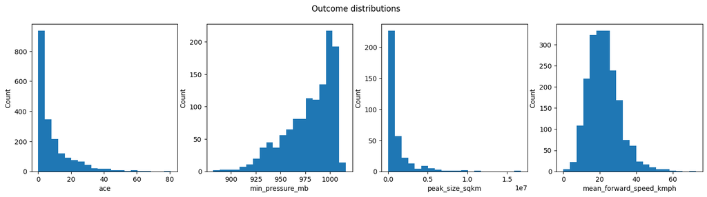

```python
outcomes = ['ace', 'min_pressure_mb', 'peak_size_sqkm', 'mean_forward_speed_kmph']

fig, ax = plt.subplots(nrows = 1, ncols = 4, figsize=(18,4))
for i, col in enumerate(outcomes):
  ax[i].hist(df[col], bins=20)
  ax[i].set_xlabel(col)
  ax[i].set_ylabel("Count")
fig.suptitle("Outcome distributions")
plt.show()
```

Above, we see strong skew in ACE, pressure, and size. This is expected since stronger storms (higher ACE and size, lower pressure) are relatively rare. Forward speed exhibits behavior much closer to a bell curve, with weaker skew.

Next, we plot each of our main predictors (ignoring the lead-time variants) against our four outcome variables, in order to determine whether there are any promising relationships and - more importantly - to see whether any plots suggest a non-linear relationship in which case we would consider a transformation of the feature to better fit our linear regression models.

```python
#STEP 2: Generate scatter plots between predictors and targets
#2.1 Define variable groups

air_vars = [
    ("air_temp_250mb", "Air Temp (250 mb)", "K"),
    ("air_temp_500mb", "Air Temp (500 mb)", "K"),
]

amo_vars = [
    ("amo", "Atlantic Multidecadal Oscillation (AMO)", ""),
]

nao_vars = [
    ("nao", "North Atlantic Oscillation (NAO)", ""),
]

rhum_vars = [
    ("rhum_minus_0_days",  "RH (0-day lead)",  "%"),
]

sst_vars = [
    ("sst_minus_0_days",  "SST (0-day lead)",  "°C"),
]

vws_vars = [
    ("vws_minus_0_days",  "VWS (0-day lead)",  "m/s"),
]

cape_vars = [
    ("cape_minus_0_days", "CAPE (0-day lead)", "J/kg"),
]

aew_strength_vars = [
    ("aew_strength_minus_0_days", "AEW strength (0-day lead)", "s$^{-1}$"),
]

#Predictor groups added
predictor_groups = {
    "air": air_vars,
    "amo": amo_vars,
    "nao": nao_vars,
    "rhum": rhum_vars,
    "sst": sst_vars,
    "vws": vws_vars,
    "cape": cape_vars,
    "aew": aew_strength_vars,
}

#2.2 Define outcomes
#Outcome_files = ['ace','pressure','size','forward_speed']

outcomes = {
    "ace": {
        "col": "ace",
        "label": "ACE (Accumulated Cyclone Energy)",
    },
    "pressure": {
        "col": "min_pressure_mb",
        "label": "Minimum Pressure (mb)",
    },
    "size": {
        "col": "peak_size_sqkm",
        "label": "Peak Size (km$^2$)",
    },
    "forward_speed": {
        "col": "mean_forward_speed_kmph",
        "label": "Mean Forward Speed (km/hr)",
    },
}
```

```python
#2.3 Make function
def plot_all_predictors_vs_target(data, predictor_groups, target_col, target_label, cols=3):

    #Flatten data
    all_vars = []
    for group in predictor_groups.values():
        all_vars.extend(group)

    n = len(all_vars)
    rows = math.ceil(n / cols)

    #Figure and axes
    fig, axes = plt.subplots(
        rows, cols,
        figsize=(cols * 4.5, rows * 3.6),
        squeeze=False
    )
    axes = axes.flatten()

    #Colorbar space
    fig.subplots_adjust(
        left=0.08,
        right=0.86,
        top=0.90,
        bottom=0.08,
        hspace=0.35,  #Vertical spacing between rows
        wspace=0.25   #Horizontal spacing between columns
    )

    #Shared colorbar
    years = data["year"].dropna()
    norm = plt.Normalize(vmin=years.min(), vmax=years.max())
    cmap = "inferno"

    first_scatter = None

    #Plotting data
    for i, (col, label, unit) in enumerate(all_vars):
        ax = axes[i]
        sub = data.dropna(subset=[col, target_col, "year"])

        sc = ax.scatter(
            sub[col], sub[target_col],
            c=sub["year"],
            cmap=cmap,
            norm=norm,
            s=12,
            alpha=0.7
        )

        if first_scatter is None:
            first_scatter = sc

        ax.set_title(label, fontsize=10)
        ax.set_xlabel(label if unit == "" else f"{label} ({unit})", fontsize=8)
        ax.set_ylabel(target_label, fontsize=8)
        ax.grid(True, alpha=0.2)

    #Remove unused axes (if any)
    for j in range(n, len(axes)):
        fig.delaxes(axes[j])

    #Bar
    cbar = fig.colorbar(
        first_scatter,
        ax=axes,
        orientation="vertical",
        fraction=0.04,   #Width of colorbar
        pad=0.02         #Distance from plots
    )
    cbar.set_label("Year", fontsize=10)
    cbar.ax.tick_params(labelsize=8)

    #Main title
    fig.suptitle(f"{target_label} vs Predictors", fontsize=16, fontweight="bold")

    plt.show()
```

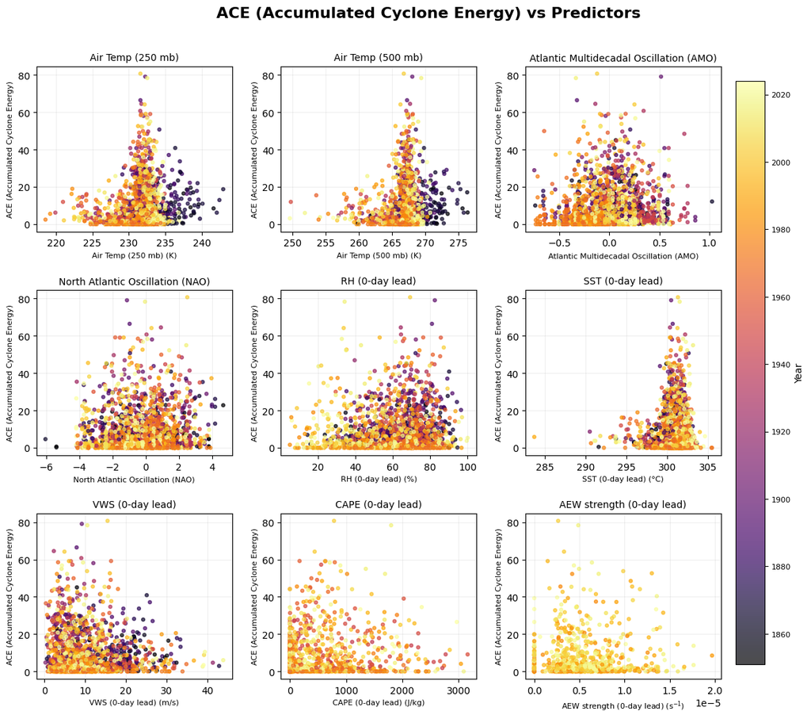

```python
#2.4 Plot for ACE
plot_all_predictors_vs_target(
   data=df,
   predictor_groups=predictor_groups,
   target_col="ace",
   target_label="ACE (Accumulated Cyclone Energy)",
   cols=3
)
```

#### Predictor relationships with ACE

Air Temperature (250 mb): Very weak relationship; high and low ACE occur across the entire temperature range.

North Atlantic Oscillation (NAO): No obvious trend as ACE spans across NAO values with little structure.

Relative Humidity (RH, 0-day lead): High ACE storms typically require at least moderate humidity, but the overall relationship is weak.

Sea Surface Temperature (SST, 0-day lead): Clear threshold of ACE as it increases strongly when SST exceeds ~27°C or 300K, showing the tempereature must be within certain values to create high ACE.

Vertical Wind Shear (VWS, 0-day lead): High ACE storms occur only under low-to-moderate shear, high shear resultes to ACE.

African Easterly Wave (AEW) Strength: Moderate wave strength supports higher ACE, but strong waves alone do not guarantee intense storms.

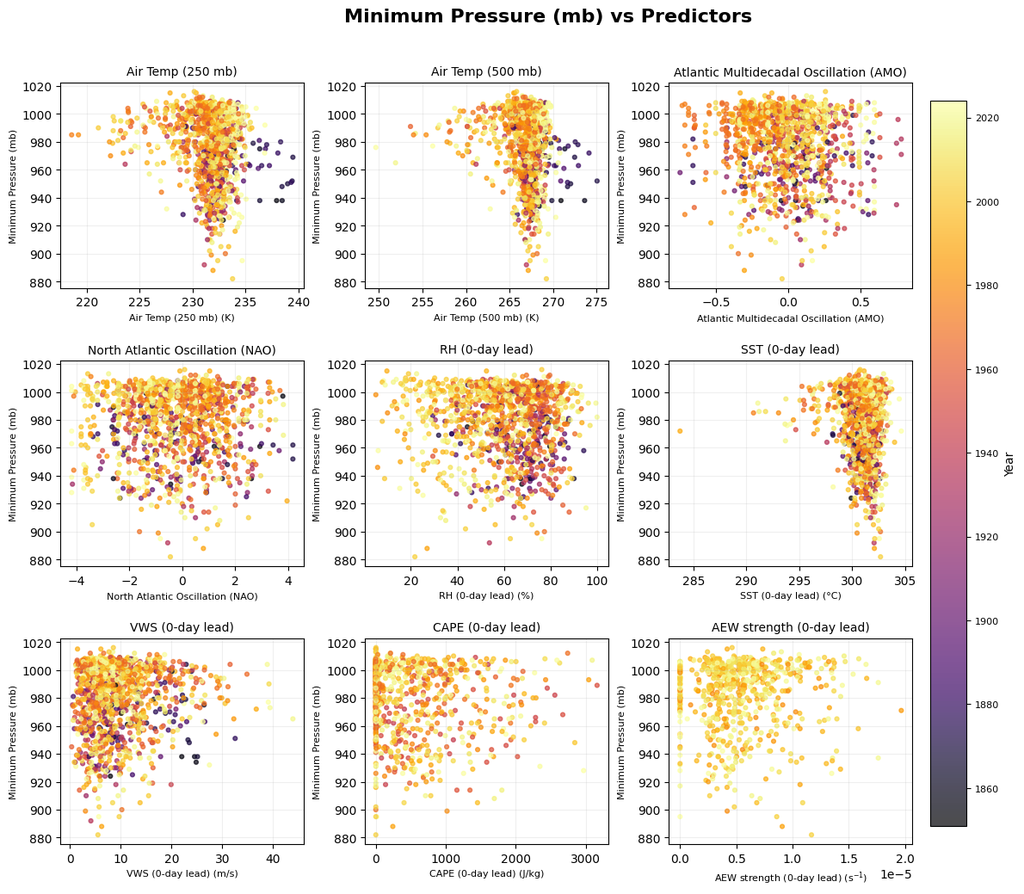

```python
#2.5 Plot for Minimum Pressure
plot_all_predictors_vs_target(
   data=df,
   predictor_groups=predictor_groups,
   target_col="min_pressure_mb",
   target_label="Minimum Pressure (mb)",
   cols=3
)
```

#### Predictor relationships with Minimum Central Pressure (mb)

Air Temperature (250 mb): Show no strong or consistent relationship with minimum pressure, indicating only a weak and noisy influence on storm intensity (ACE).

Air Temperature (500 mb): Show no strong or consistent relationship with minimum pressure, suggesting mid-level warmth alone does not determine storm strength.

Atlantic Multidecadal Oscillation (AMO): Has scattered plots, indicating the relationship is loose in between the two.

North Atlantic Oscillation (NAO): NAO shows no meaningful relationship with minimum pressure, as storms occur across the full pressure range regardless of NAO value.

Relative Humidity (RH, 0-day lead): The relationship is weak, slightly negative relationship—higher relative humidity is loosely associated with lower minimum pressures, but the pattern is very scattered and not strongly predictive.

Sea Surface Temperature (SST, 0-day lead): Warmer SSTs show a clearer tendency toward lower minimum pressures, consistent with warm water fueling stronger storms.

Vertical Wind Shear (VWS, 0-day lead): Stronger vertical wind shear is associated with higher minimum pressures, showing that shear inhibits storm deepening.

CAPE (0-day lead): Higher CAPE does not show a clean relationship with pressure, suggesting instability alone is insufficient for storm intensification.

African Easterly Wave (AEW) Strength: Lower AEW strength shows only a weak tendency to the higher pressure, though it is weak.

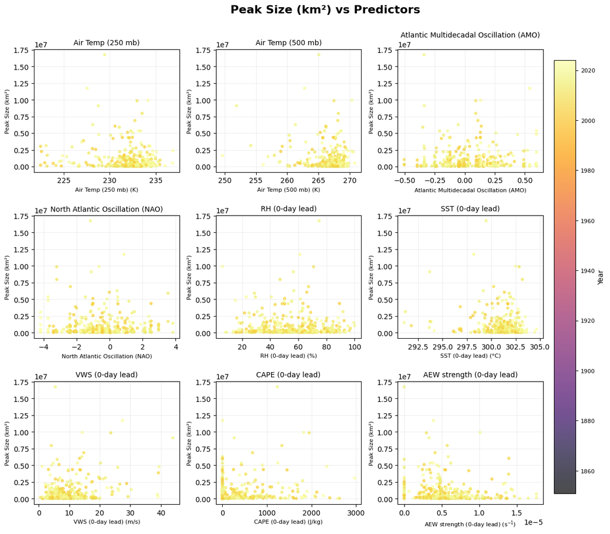

```python
#2.4 Plot for Peak Size
plot_all_predictors_vs_target(
   data=df,
   predictor_groups=predictor_groups,
   target_col="peak_size_sqkm",
   target_label="Peak Size (km²)",
   cols=3
)
```

#### Predictor relationships with Maximum Storm Size (km$^2$)

Air Temperature (250 mb): There is no clear relationship between 250 mb temperature and peak size, with storms of all sizes occurring across the full temperature range.

Air Temperature (500 mb): Show no strong or consistent relationship with peak size.

Atlantic Multidecadal Oscillation (AMO): AMO displays a weak and scattered relationship with peak size.

North Atlantic Oscillation (NAO): NNO shows no noticable relationship with storm peak size, as storms of all sizes form under both positive and negative NAO values.

Relative Humidity (RH, 0-day lead): Relative humidity presents a very weak relationship with peak size, moisuture availability alone does not determine peak size storm.

Sea Surface Temperature (SST, 0-day lead): Warmer SSTs show a small tendency toward higher peak size, although it is weak.

Vertical Wind Shear (VWS, 0-day lead): Peak size seems to have no effect by varying wind shear.

CAPE (0-day lead): Peak size seems to have no effect by varying CAPE.

African Easterly Wave (AEW) Strength: AEW strength has a weak and inconsistent relationship with peak size.

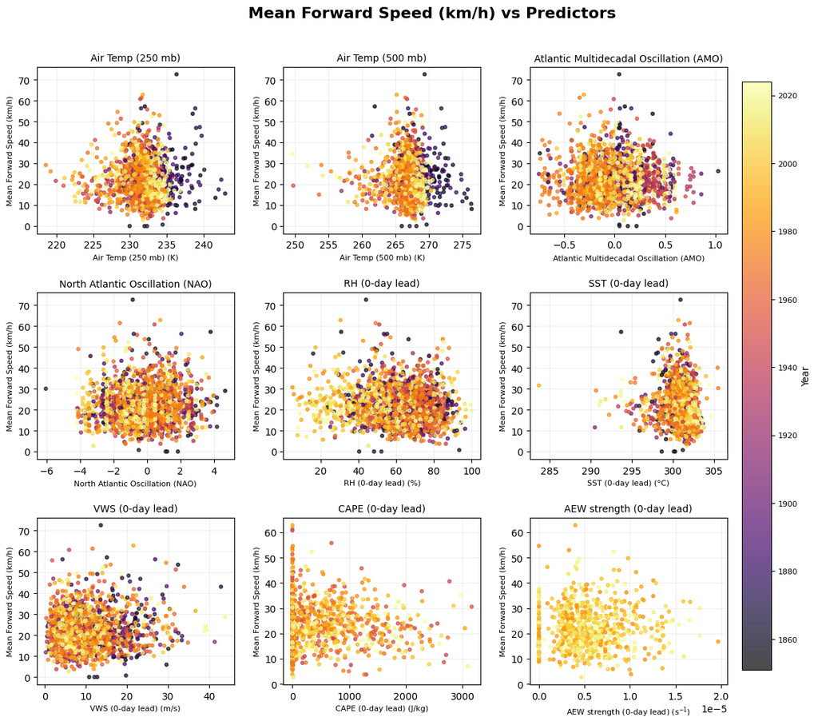

```python
#2.4 Plot for Forward Speed
plot_all_predictors_vs_target(
   data=df,
   predictor_groups=predictor_groups,
   target_col="mean_forward_speed_kmph",
   target_label="Mean Forward Speed (km/h)",
   cols=3
)
```

#### Predictor relationships with Mean Forward Speed

Air Temperature (250 mb): Forward speed shows no clear relationship with 250 mb air temperature, as storms at all temperatures travel at a wide range of speeds.

Air Temperature (500 mb): There is no clear relationship between 500 mb air temperature and forward speed, with the data showing a fully scattered pattern.

Atlantic Multidecadal Oscillation (AMO): AMO exhibits little forward speed, indicating that basin-scale warming phases do not strongly influence storm motion

North Atlantic Oscillation (NAO): NAO shows inconsistent relationship with forward speed, as storms move at similar speeds across both positive and negative NAO states.

Relative Humidity (RH, 0-day lead): Relative humidity shows inconsistent relationship with forward speed.

Sea Surface Temperature (SST, 0-day lead): SST shows no strong relationship with forward speed, warm water may affect storm intensity but potentially not how fast storms travel.

CAPE (0-day lead): Very weak positive trend; There is no observable relationship between CAPE and forward speed, indicating that atmospheric instability does not control storm motion.

African Easterly Wave (AEW) Strength:: No strong AEW can determine the forward speed alone.

We also examine the summary statistics for our predictors:

```python
#Summary Statistics (mean, median, std, etc.)
summary_stats = df.describe(include="all").transpose()
print("Summary statistics for predictors & observed data:")
summary_stats
```

```
Summary statistics for predictors & observed data:
```

|  | count | mean | std | min | 25% | 50% | 75% | max |
| --- | --- | --- | --- | --- | --- | --- | --- | --- |
| formation_lat | 1983.0 | 2.051523e+01 | 7.479430e+00 | 7.000000 | 14.000000 | 19.700000 | 2.600000e+01 | 4.720000e+01 |
| formation_lon | 1983.0 | 2.966727e+02 | 2.158036e+01 | 262.000000 | 279.000000 | 293.400000 | 3.125000e+02 | 3.460000e+02 |
| year | 1983.0 | 1.954294e+03 | 4.858137e+01 | 1851.000000 | 1916.000000 | 1965.000000 | 1.995000e+03 | 2.024000e+03 |
| day_of_year | 1983.0 | 2.452133e+02 | 4.345592e+01 | 1.000000 | 225.000000 | 250.000000 | 2.730000e+02 | 3.640000e+02 |
| ace | 1983.0 | 8.891036e+00 | 1.115610e+01 | 0.000000 | 1.570000 | 4.552500 | 1.197625e+01 | 8.072750e+01 |
| min_pressure_mb | 1233.0 | 9.792749e+02 | 2.471667e+01 | 882.000000 | 964.000000 | 986.000000 | 1.000000e+03 | 1.016000e+03 |
| peak_size_sqkm | 346.0 | 1.092604e+06 | 1.858695e+06 | 4310.144484 | 116373.901056 | 377137.642312 | 1.279035e+06 | 1.675784e+07 |
| mean_forward_speed_kmph | 1952.0 | 2.217499e+01 | 8.697269e+00 | 0.000000 | 16.151906 | 21.374126 | 2.690463e+01 | 7.259285e+01 |
| aew_strength_minus_0_days | 737.0 | 5.300033e-06 | 3.617324e-06 | 0.000000 | 0.000003 | 0.000005 | 7.347197e-06 | 1.967688e-05 |
| aew_strength_minus_2_days | 737.0 | 5.046818e-06 | 3.517772e-06 | 0.000000 | 0.000003 | 0.000004 | 7.235939e-06 | 1.884974e-05 |
| aew_strength_minus_3_days | 737.0 | 5.369414e-06 | 3.763573e-06 | 0.000000 | 0.000003 | 0.000005 | 7.518204e-06 | 3.579521e-05 |
| air_temp_250mb | 1983.0 | 2.318342e+02 | 2.420103e+00 | 218.578903 | 230.979584 | 232.009995 | 2.330190e+02 | 2.429035e+02 |
| air_temp_500mb | 1983.0 | 2.670119e+02 | 2.264974e+00 | 249.649994 | 266.407440 | 267.261902 | 2.679891e+02 | 2.764129e+02 |
| amo | 1983.0 | -6.153409e-03 | 2.623877e-01 | -0.751894 | -0.174530 | -0.008193 | 1.549309e-01 | 1.028202e+00 |
| cape_minus_0_days | 1281.0 | 4.062823e+02 | 6.102988e+02 | 0.000000 | 0.000000 | 31.375000 | 6.390000e+02 | 3.161875e+03 |
| cape_minus_2_days | 1281.0 | 4.271652e+02 | 6.027643e+02 | 0.000000 | 0.000000 | 67.750000 | 7.210000e+02 | 3.666750e+03 |
| cape_minus_3_days | 1281.0 | 4.394400e+02 | 6.277868e+02 | 0.000000 | 0.125000 | 69.750000 | 7.040000e+02 | 3.658250e+03 |
| nao | 1983.0 | -1.537973e-01 | 1.625770e+00 | -6.050000 | -1.215000 | -0.080000 | 8.900000e-01 | 4.680000e+00 |
| rhum_minus_0_days | 1983.0 | 6.088932e+01 | 1.701300e+01 | 4.989990 | 50.650532 | 63.285076 | 7.288349e+01 | 1.000000e+02 |
| rhum_minus_3_days | 1983.0 | 4.949644e+01 | 1.856129e+01 | 0.000000 | 37.250000 | 51.250000 | 6.257867e+01 | 9.999001e+01 |
| rhum_minus_7_days | 1983.0 | 4.770478e+01 | 1.819503e+01 | 0.000000 | 35.750000 | 49.500000 | 6.038208e+01 | 9.899001e+01 |
| rhum_minus_14_days | 1983.0 | 4.746385e+01 | 1.770409e+01 | 0.239990 | 35.036512 | 48.580784 | 6.057117e+01 | 9.849001e+01 |
| sst_minus_0_days | 1983.0 | 3.009465e+02 | 1.590206e+00 | 283.730000 | 300.410658 | 301.231964 | 3.018930e+02 | 3.054948e+02 |
| sst_minus_3_days | 1983.0 | 3.010280e+02 | 1.580624e+00 | 284.320000 | 300.431018 | 301.282135 | 3.019828e+02 | 3.060264e+02 |
| sst_minus_7_days | 1983.0 | 3.010435e+02 | 1.598916e+00 | 285.119999 | 300.434189 | 301.266479 | 3.020246e+02 | 3.048300e+02 |
| sst_minus_14_days | 1983.0 | 3.009964e+02 | 1.600547e+00 | 285.470000 | 300.339999 | 301.228485 | 3.019704e+02 | 3.054066e+02 |
| vws_minus_0_days | 1983.0 | 1.021595e+01 | 6.643299e+00 | 0.217294 | 5.494682 | 8.618414 | 1.338928e+01 | 4.391889e+01 |
| vws_minus_3_days | 1983.0 | 1.163768e+01 | 7.556522e+00 | 0.184332 | 6.238358 | 9.978223 | 1.538804e+01 | 5.055669e+01 |
| vws_minus_7_days | 1983.0 | 1.116301e+01 | 7.080207e+00 | 0.111790 | 6.229500 | 9.698967 | 1.438531e+01 | 4.618093e+01 |
| vws_minus_14_days | 1983.0 | 1.083590e+01 | 6.905453e+00 | 0.235066 | 5.791018 | 9.445719 | 1.429260e+01 | 4.557080e+01 |

The data describes many standard outcome distributions, and the summary statistics reflect the same patterns, showing that most outcomes are highly skewed. The dataset includes 1,983 storms, merged with several additional datasets whose time ranges and data granularities differ. The outcome variables tend to be skewed with extreme storms driving much of the variation. This is reflected in their large standard deviations, such as peak size (std ≈ 1.86×10⁶ km²).

Meanwhile, the environmental predictors shows broad natural variability but generally have more moderate standard deviations, such as SST (std ≈ 1.59 K), relative humidity (std ≈ 17%), and mid- and upper-level temperatures. These SD values indicate that predictors vary across storms and lead times. Generally, the dataset provides both high-variance outcomes and diverse predictor ranges.

## 7. Forecasting and prediction modeling

We aimed to predict a cyclone’s destructive potential using only formation-day conditions, using ACE, minimum central pressure, maximum storm size, and mean forward speed as our outcomes.

For each problem, we prepared the dataset by removing rows with missing predictor values and generating design matrices containing all relevant formation-day variables. Features were scaled within the modeling pipeline, using standardization for roughly normal distributions and min-max scaling for highly skewed features.

We tested eight regression approaches, representing both linear and nonlinear learning methods:

- Forward stepwise selection
- Backward stepwise selection
- LASSO regression
- Ridge regression
- k-Nearest Neighbors
- Simple decision tree
- Random forest
- Gradient boosting

For each method, we performed 5-fold cross-validation to select optimal hyperparameters (e.g. number of neighbors, regularization strengths, tree depth, number of estimators).

### 7.1 Decorrelation

Next, we suspect there may be collinearity among some of our features, especially since in some cases we are using the same indicator with different days of lead time. We use a correlation matrix to locate collinearity above 80%.

```python
results = df.corr().abs() > 0.8

def highlight_true(val):
    color = 'red' if val == True else ''
    return f'background-color: {color}'

results.style.map(highlight_true)
```

|  | formation_lat | formation_lon | year | day_of_year | ace | min_pressure_mb | peak_size_sqkm | mean_forward_speed_kmph | aew_strength_minus_0_days | aew_strength_minus_2_days | aew_strength_minus_3_days | air_temp_250mb | air_temp_500mb | amo | cape_minus_0_days | cape_minus_2_days | cape_minus_3_days | nao | rhum_minus_0_days | rhum_minus_3_days | rhum_minus_7_days | rhum_minus_14_days | sst_minus_0_days | sst_minus_3_days | sst_minus_7_days | sst_minus_14_days | vws_minus_0_days | vws_minus_3_days | vws_minus_7_days | … |
| --- | --- | --- | --- | --- | --- | --- | --- | --- | --- | --- | --- | --- | --- | --- | --- | --- | --- | --- | --- | --- | --- | --- | --- | --- | --- | --- | --- | --- | --- | --- |
| formation_lat | True | False | False | False | False | False | False | False | False | False | False | False | False | False | False | False | False | False | False | False | False | False | False | False | False | False | False | False | False | … |
| formation_lon | False | True | False | False | False | False | False | False | False | False | False | False | False | False | False | False | False | False | False | False | False | False | False | False | False | False | False | False | False | … |
| year | False | False | True | False | False | False | False | False | False | False | False | False | False | False | False | False | False | False | False | False | False | False | False | False | False | False | False | False | False | … |
| day_of_year | False | False | False | True | False | False | False | False | False | False | False | False | False | False | False | False | False | False | False | False | False | False | False | False | False | False | False | False | False | … |
| ace | False | False | False | False | True | True | False | False | False | False | False | False | False | False | False | False | False | False | False | False | False | False | False | False | False | False | False | False | False | … |
| min_pressure_mb | False | False | False | False | True | True | False | False | False | False | False | False | False | False | False | False | False | False | False | False | False | False | False | False | False | False | False | False | False | … |
| peak_size_sqkm | False | False | False | False | False | False | True | False | False | False | False | False | False | False | False | False | False | False | False | False | False | False | False | False | False | False | False | False | False | … |
| mean_forward_speed_kmph | False | False | False | False | False | False | False | True | False | False | False | False | False | False | False | False | False | False | False | False | False | False | False | False | False | False | False | False | False | … |
| aew_strength_minus_0_days | False | False | False | False | False | False | False | False | True | False | False | False | False | False | False | False | False | False | False | False | False | False | False | False | False | False | False | False | False | … |
| aew_strength_minus_2_days | False | False | False | False | False | False | False | False | False | True | False | False | False | False | False | False | False | False | False | False | False | False | False | False | False | False | False | False | False | … |
| aew_strength_minus_3_days | False | False | False | False | False | False | False | False | False | False | True | False | False | False | False | False | False | False | False | False | False | False | False | False | False | False | False | False | False | … |
| air_temp_250mb | False | False | False | False | False | False | False | False | False | False | False | True | True | False | False | False | False | False | False | False | False | False | False | False | False | False | False | False | False | … |
| air_temp_500mb | False | False | False | False | False | False | False | False | False | False | False | True | True | False | False | False | False | False | False | False | False | False | False | False | False | False | False | False | False | … |
| amo | False | False | False | False | False | False | False | False | False | False | False | False | False | True | False | False | False | False | False | False | False | False | False | False | False | False | False | False | False | … |
| cape_minus_0_days | False | False | False | False | False | False | False | False | False | False | False | False | False | False | True | False | False | False | False | False | False | False | False | False | False | False | False | False | False | … |
| cape_minus_2_days | False | False | False | False | False | False | False | False | False | False | False | False | False | False | False | True | False | False | False | False | False | False | False | False | False | False | False | False | False | … |
| cape_minus_3_days | False | False | False | False | False | False | False | False | False | False | False | False | False | False | False | False | True | False | False | False | False | False | False | False | False | False | False | False | False | … |
| nao | False | False | False | False | False | False | False | False | False | False | False | False | False | False | False | False | False | True | False | False | False | False | False | False | False | False | False | False | False | … |
| rhum_minus_0_days | False | False | False | False | False | False | False | False | False | False | False | False | False | False | False | False | False | False | True | False | False | False | False | False | False | False | False | False | False | … |
| rhum_minus_3_days | False | False | False | False | False | False | False | False | False | False | False | False | False | False | False | False | False | False | False | True | False | False | False | False | False | False | False | False | False | … |
| rhum_minus_7_days | False | False | False | False | False | False | False | False | False | False | False | False | False | False | False | False | False | False | False | False | True | False | False | False | False | False | False | False | False | … |
| rhum_minus_14_days | False | False | False | False | False | False | False | False | False | False | False | False | False | False | False | False | False | False | False | False | False | True | False | False | False | False | False | False | False | … |
| sst_minus_0_days | False | False | False | False | False | False | False | False | False | False | False | False | False | False | False | False | False | False | False | False | False | False | True | True | True | True | False | False | False | … |
| sst_minus_3_days | False | False | False | False | False | False | False | False | False | False | False | False | False | False | False | False | False | False | False | False | False | False | True | True | True | True | False | False | False | … |
| sst_minus_7_days | False | False | False | False | False | False | False | False | False | False | False | False | False | False | False | False | False | False | False | False | False | False | True | True | True | True | False | False | False | … |
| sst_minus_14_days | False | False | False | False | False | False | False | False | False | False | False | False | False | False | False | False | False | False | False | False | False | False | True | True | True | True | False | False | False | … |
| vws_minus_0_days | False | False | False | False | False | False | False | False | False | False | False | False | False | False | False | False | False | False | False | False | False | False | False | False | False | False | True | False | False | … |
| vws_minus_3_days | False | False | False | False | False | False | False | False | False | False | False | False | False | False | False | False | False | False | False | False | False | False | False | False | False | False | False | True | False | … |
| vws_minus_7_days | False | False | False | False | False | False | False | False | False | False | False | False | False | False | False | False | False | False | False | False | False | False | False | False | False | False | False | False | True | … |
| vws_minus_14_days | False | False | False | False | False | False | False | False | False | False | False | False | False | False | False | False | False | False | False | False | False | False | False | False | False | False | False | False | False | … |

Fortunately, the only correlation among predictors is the four instances of sea surface temperature and the two instances of tropospheric air temperature. We drop all the lead-time SST columns and the 500 mb air temperature as a result, since we care more about SST on day-of-formation and the 250 mb temperature is more of a signature of tropical cyclones.

```python
df.drop(inplace=True, columns=['sst_minus_3_days','sst_minus_7_days','sst_minus_14_days', "air_temp_500mb"])
```

### 7.2 Scaling

We plan to scale our features during the training pipeline so that features with high numbers (like CAPE) and those with small numbers (like AEW strength) are treated evenly. We will use either min-max scaling or standardization, depending on whether the feature is roughly normally distributed or not.

We plot histograms for all predictors in order to ascertain their distribution shapes:

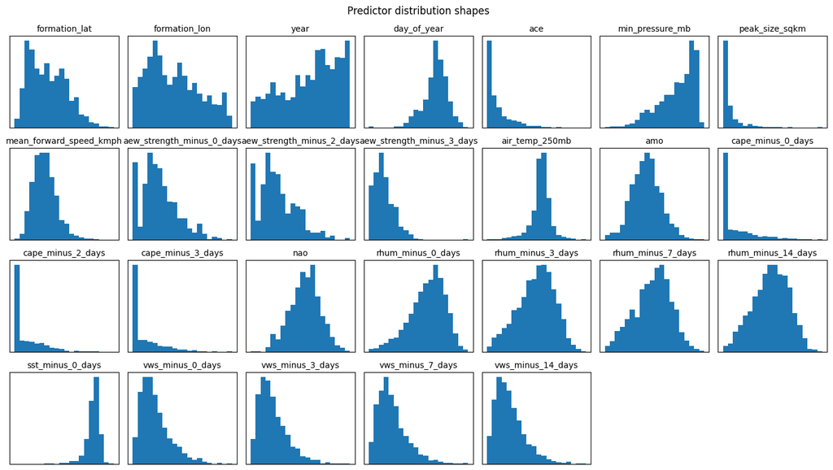

```python
fig, ax = plt.subplots(nrows = 4, ncols = 7, figsize = (7*2, 4*2))
for i, plot in enumerate(ax.flatten()):
	if i < len(df.columns):
		plot = ax[i // 7][i % 7]
		plot.hist(df[df.columns[i]], bins = 20)
		plot.set_title(df.columns[i], fontsize=10)
		plot.set_xlabel("")
		plot.set_ylabel("")
		plot.set_xticks([])
		plot.set_yticks([])
		plot.set_xticklabels([])
		plot.set_yticklabels([])
	else:
		plot.axis('off')

fig.suptitle("Predictor distribution shapes")
fig.tight_layout()
plt.show()
```

From this visualization, the predictors that are least appropriate for standardization are year, CAPE, and AEW strength, so we will use min-max scaling for those, and standardization on the others.

### 7.3 Training

Here, we compare eight regression methods:

- Forward stepwise selection
- Backward stepwise selection
- LASSO regression
- Ridge regression
- k-Nearest Neighbors
- Simple decision tree
- Random forest
- Gradient boosting

In order to streamline our training procedure, we define each problem as a set of attributes (time bounds, outcome, and predictors) that we can feed into reusable functions.

We define five problems in a configuration object. Four represent the four outcome variables of interest: ACE, minimum central pressure, maximum storm size, and mean forward speed. Depending on the time range for these outcome labels, we use start and end years to truncate the rows and choose predictors where we have 95% coverage, dropping the last few rows containing any null values.

The fifth problem again considers our primary prediction question: ACE. This time, we restrict our time frame to the "satellite era" of meteorology, beginning in 1979, so that we can make use of relevant predictors like CAPE and AEW strength.

```python
problems = {
	"ace_all": {
		"start_year": 1851,
		"end_year": 2024,
		"outcome": "ace",
		"predictors": [
			'formation_lat', 'formation_lon', 'year', 'day_of_year',
			'air_temp_250mb', 'amo', 'nao',
			'rhum_minus_0_days', 'rhum_minus_3_days', 'rhum_minus_7_days', 'rhum_minus_14_days',
			'sst_minus_0_days',
			'vws_minus_0_days', 'vws_minus_3_days', 'vws_minus_7_days', 'vws_minus_14_days'
		]
	},
	"ace_satellite": {
		"start_year": 1979,
		"end_year": 2023,
		"outcome": "ace",
		"predictors": [
			'formation_lat', 'formation_lon', 'year', 'day_of_year',
			'aew_strength_minus_0_days', 'aew_strength_minus_2_days', 'aew_strength_minus_3_days',
			'air_temp_250mb', 'amo',
			'cape_minus_0_days', 'cape_minus_2_days', 'cape_minus_3_days', 'nao',
			'rhum_minus_0_days', 'rhum_minus_3_days', 'rhum_minus_7_days', 'rhum_minus_14_days',
			'sst_minus_0_days',
			'vws_minus_0_days', 'vws_minus_3_days', 'vws_minus_7_days', 'vws_minus_14_days'
		]
	},
	"pressure": {
		"start_year": 1851,
		"end_year": 2024,
		"outcome": "min_pressure_mb",
		"predictors": [
			'formation_lat', 'formation_lon', 'year', 'day_of_year',
			'air_temp_250mb', 'amo', 'nao',
			'rhum_minus_0_days', 'rhum_minus_3_days', 'rhum_minus_7_days', 'rhum_minus_14_days',
			'sst_minus_0_days',
			'vws_minus_0_days', 'vws_minus_3_days', 'vws_minus_7_days', 'vws_minus_14_days'
		]
	},
	"size": {
		"start_year": 2004,
		"end_year": 2023,
		"outcome": "peak_size_sqkm",
		"predictors": [
			'formation_lat', 'formation_lon', 'year', 'day_of_year',
			'aew_strength_minus_0_days', 'aew_strength_minus_2_days', 'aew_strength_minus_3_days',
			'air_temp_250mb', 'amo',
			'cape_minus_0_days', 'cape_minus_2_days', 'cape_minus_3_days', 'nao',
			'rhum_minus_0_days', 'rhum_minus_3_days', 'rhum_minus_7_days', 'rhum_minus_14_days',
			'sst_minus_0_days',
			'vws_minus_0_days', 'vws_minus_3_days', 'vws_minus_7_days', 'vws_minus_14_days'
		]
	},
	"forward_speed": {
		"start_year": 1871,
		"end_year": 2024,
		"outcome": "mean_forward_speed_kmph",
		"predictors": [
			'formation_lat', 'formation_lon', 'year', 'day_of_year',
			'air_temp_250mb', 'amo', 'nao',
			'rhum_minus_0_days', 'rhum_minus_3_days', 'rhum_minus_7_days', 'rhum_minus_14_days',
			'sst_minus_0_days',
			'vws_minus_0_days', 'vws_minus_3_days', 'vws_minus_7_days', 'vws_minus_14_days'
		]
	}
}
```

We now define several functions:

- One for each method of regression analysis cross-validation and final training
- A function for evaluating the performance of a model
- A "pipeline" function that accepts a problem definition, generates the design matrix appropriately, splits and scales the data, trains and evaluates the model, and appends the results to a dictionary.

We scale each feature with standardization if it is roughly bell-shaped, and with min-max if not. We must conduct scaling after the split to avoid data leakage.

For each method, we performed 5-fold cross-validation to select optimal hyperparameters (number of neighbors, regularization strengths, tree depth, number of estimators).

```python
def evaluate(model, X_train, X_test, y_train, y_test):
	y_train_pred = model.predict(X_train)
	y_test_pred = model.predict(X_test)
	train_mse = mean_squared_error(y_train, y_train_pred)
	test_mse = mean_squared_error(y_test, y_test_pred)
	train_rmse = np.sqrt(train_mse)
	test_rmse = np.sqrt(test_mse)
	train_mae = mean_absolute_error(y_train, y_train_pred)
	test_mae = mean_absolute_error(y_test, y_test_pred)
	train_r2 = r2_score(y_train, y_train_pred)
	test_r2 = r2_score(y_test, y_test_pred)
	return [train_mse, test_mse, train_rmse, test_rmse, train_mae, test_mae, train_r2, test_r2]
```

```python
def run_forward_selection(X_train, y_train):
	lrf = LinearRegression()
	sfs = SequentialFeatureSelector(lrf, direction='forward', cv=KFold(n_splits=5,shuffle=True,random_state=seed))

	pipe_lrf = Pipeline([
		('sfs', sfs),
		('model', lrf)
	])

	param_grid = {
		'sfs__n_features_to_select': range(1, X_train.shape[1])
	}

	grid_search_forward = GridSearchCV(pipe_lrf, param_grid, cv=KFold(n_splits=5,shuffle=True,random_state=seed), scoring='r2')
	grid_search_forward.fit(X_train, y_train)
	return grid_search_forward.best_estimator_
```

```python
def run_backward_selection(X_train, y_train):
	lrb = LinearRegression()
	sfs = SequentialFeatureSelector(lrb, direction='backward', cv=KFold(n_splits=5,shuffle=True,random_state=seed))

	pipe_lrb = Pipeline([
		('sfs', sfs),
		('model', lrb)
	])

	param_grid = {
		'sfs__n_features_to_select': range(1, X_train.shape[1])
	}

	grid_search_backward = GridSearchCV(pipe_lrb, param_grid, cv=KFold(n_splits=5,shuffle=True,random_state=seed), scoring='r2')
	grid_search_backward.fit(X_train, y_train)
	return grid_search_backward.best_estimator_
```

```python
def run_lasso(X_train, y_train):
	lasso_cv = LassoCV(cv=KFold(n_splits=5, shuffle=True, random_state=seed), alphas=100, random_state=seed, max_iter=5000)
	lasso_cv.fit(X_train, y_train)
	return lasso_cv
```

```python
def run_ridge(X_train, y_train):
	ridge_cv = RidgeCV(cv=KFold(n_splits=5, shuffle=True, random_state=seed), alphas=np.logspace(-3,3,50), scoring='r2')
	ridge_cv.fit(X_train, y_train)
	return ridge_cv
```

```python
def run_knn_regressor(X_train, y_train):
	pipe_knn = Pipeline([
		('knn', KNeighborsRegressor())
	])

	param_grid = {
		'knn__n_neighbors': range(1, 30)
	}

	grid_search_knn = GridSearchCV(pipe_knn, param_grid, cv=KFold(n_splits=5, shuffle=True, random_state=seed),scoring='r2')
	grid_search_knn.fit(X_train, y_train)
	return grid_search_knn.best_estimator_
```

```python
def run_decision_tree(X_train, y_train):
	dtr = DecisionTreeRegressor(random_state=seed)

	param_grid = {
		'max_depth': [1, 3, 5, 10, None],
		'min_samples_leaf': [1, 3, 5, 10],
		'min_samples_split': [2, 5, 10]
	}

	grid_search_dt = GridSearchCV(dtr, param_grid, cv=KFold(n_splits=5, shuffle=True, random_state=seed))
	grid_search_dt.fit(X_train, y_train)
	return grid_search_dt.best_estimator_
```

```python
def run_random_forest(X_train, y_train):
	rfr = RandomForestRegressor(random_state=seed)

	param_dist = {
		'n_estimators': [100, 200, 300],
		'max_features': ['sqrt'],
		'max_depth': [2, 3, 5, 7],
		'min_samples_leaf': [1, 2, 4],
		'min_samples_split': [2, 5, 10]
	}

	random_search_rf = RandomizedSearchCV(
		rfr,
		param_distributions=param_dist,
		n_iter=25,
		cv=KFold(n_splits=5, shuffle=True, random_state=seed),
		scoring='neg_mean_squared_error',
		random_state=seed,
		refit=True
	)

	random_search_rf.fit(X_train, y_train)
	return random_search_rf.best_estimator_
```

```python
def run_gradient_boosting(X_train, y_train):
	gbr = GradientBoostingRegressor(random_state=seed)

	param_dist = {
		'n_estimators': [100, 200, 500],
		'learning_rate': [0.01, 0.05, 0.1, 0.2],
		'max_depth': [3, 4, 5, 7],
		'subsample': [0.8, 0.9, 1.0]
	}

	random_search_gb = RandomizedSearchCV(
		gbr,
		param_distributions=param_dist,
		n_iter=25,
		cv=KFold(n_splits=5,shuffle=True,random_state=seed),
		scoring="neg_mean_squared_error",
		random_state=seed
	)

	random_search_gb.fit(X_train, y_train)
	return random_search_gb.best_estimator_
```

```python
def run_pipeline(id, config):
	data = df.copy()

	# drop
	mask = data.year.between(config['start_year'], config['end_year'])
	data = data[mask]
	data.dropna(inplace=True)

	# split
	X = data[config['predictors']].copy()
	y = data[config['outcome']].copy()

	X_train, X_test, y_train, y_test = train_test_split(X, y, test_size = 0.2, random_state = seed)

	# scale
	if config['start_year'] >= 1979:
		minmax_cols = [
			'aew_strength_minus_0_days', 'aew_strength_minus_2_days', 'aew_strength_minus_3_days',
			'cape_minus_0_days', 'cape_minus_2_days', 'cape_minus_3_days',
			'year'
		]
	else:
		minmax_cols = ['year']
	standard_cols = [
		'formation_lat', 'formation_lon', 'day_of_year',
		'air_temp_250mb', 'amo', 'nao',
		'rhum_minus_0_days', 'rhum_minus_3_days', 'rhum_minus_7_days', 'rhum_minus_14_days',
		'sst_minus_0_days',
		'vws_minus_0_days', 'vws_minus_3_days', 'vws_minus_7_days', 'vws_minus_14_days'
	]

	preprocessor = ColumnTransformer(
		transformers = [
			('minmax', MinMaxScaler(), minmax_cols),
			('standard', StandardScaler(), standard_cols),
		],
		remainder = 'passthrough'
	)

	X_train = preprocessor.fit_transform(X_train)
	X_test = preprocessor.transform(X_test)
	X_train.columns = minmax_cols + standard_cols # Rename to get rid of the scaler prefixes that got added
	X_test.columns = minmax_cols + standard_cols

	# model
	scores = pd.DataFrame(columns=['train_mse','test_mse', 'train_rmse','test_rmse','train_mae', 'test_mae', 'train_r2', 'test_r2'])
	best_models = {}

	methods = ["Forward selection", "Backward selection", "Lasso", "Ridge", "KNN", "Decision tree", "Random forest", "Gradient boosting"]
	routines = [run_forward_selection, run_backward_selection, run_lasso, run_ridge, run_knn_regressor, run_decision_tree, run_random_forest, run_gradient_boosting]

	for j, routine in enumerate(routines):
		model = routine(X_train, y_train)
		scores.loc[methods[j]] = evaluate(model, X_train, X_test, y_train, y_test)
		best_models[methods[j]] = model

	results[id] = {
		"scores": scores,
		"best_models": best_models,
		"X_train": X_train,
		"y_train": y_train,
		"X_test": X_test,
		"y_test": y_test
	}
```

Here, we run our routines on all problem definitions. The result is a dictionary object containing the 8 best models for each regression method and a table of loss statistics, for each problem.

```python
results = {}
for id, config in problems.items():
	run_pipeline(id, config) # ONLY UNCOMMENT AND RUN WHEN YOU CAN WAIT 15+ MINUTES
	print(f"===== {id} =====")
	display(results[id]['scores'])
```

```
===== ace_all =====
```

|  | train_mse | test_mse | train_rmse | test_rmse | train_mae | test_mae | train_r2 | test_r2 |
| --- | --- | --- | --- | --- | --- | --- | --- | --- |
| Forward selection | 123.459267 | 163.913194 | 11.111223 | 12.802859 | 7.559638 | 9.208173 | 0.177704 | -0.003837 |
| Backward selection | 128.485244 | 148.668652 | 11.335133 | 12.192976 | 7.573562 | 8.553749 | 0.144228 | 0.089524 |
| Lasso | 124.864092 | 154.511951 | 11.174260 | 12.430284 | 7.489016 | 8.941331 | 0.168347 | 0.053738 |
| Ridge | 124.988281 | 156.537829 | 11.179816 | 12.511508 | 7.526929 | 9.051836 | 0.167520 | 0.041331 |
| KNN | 128.893129 | 155.026299 | 11.353111 | 12.450956 | 7.768488 | 9.178344 | 0.141512 | 0.050588 |
| Decision tree | 130.179446 | 171.477419 | 11.409621 | 13.094939 | 7.908685 | 8.781389 | 0.132944 | -0.050162 |
| Random forest | 69.888339 | 153.583523 | 8.359925 | 12.392882 | 5.493054 | 8.779360 | 0.534511 | 0.059424 |
| Gradient boosting | 40.273589 | 155.875453 | 6.346148 | 12.485009 | 4.714362 | 8.551202 | 0.731759 | 0.045388 |

```
===== ace_satellite =====
```

|  | train_mse | test_mse | train_rmse | test_rmse | train_mae | test_mae | train_r2 | test_r2 |
| --- | --- | --- | --- | --- | --- | --- | --- | --- |
| Forward selection | 127.004889 | 139.437203 | 11.269645 | 11.808353 | 7.719464 | 8.145607 | 0.186398 | 0.031942 |
| Backward selection | 133.030473 | 130.999409 | 11.533884 | 11.445497 | 7.701146 | 7.758358 | 0.147798 | 0.090522 |
| Lasso | 132.916195 | 133.279960 | 11.528929 | 11.544694 | 7.724453 | 7.572096 | 0.148530 | 0.074690 |
| Ridge | 126.536351 | 135.292061 | 11.248838 | 11.631512 | 7.635274 | 7.641989 | 0.189400 | 0.060720 |
| KNN | 129.686916 | 137.639358 | 11.388016 | 11.731980 | 7.825112 | 7.889172 | 0.169217 | 0.044424 |
| Decision tree | 135.980083 | 146.324000 | 11.661050 | 12.096446 | 7.796483 | 8.388681 | 0.128903 | -0.015870 |
| Random forest | 70.070363 | 140.009810 | 8.370804 | 11.832574 | 5.472564 | 7.931314 | 0.551125 | 0.027967 |
| Gradient boosting | 50.966096 | 141.585123 | 7.139054 | 11.898955 | 5.301614 | 8.118921 | 0.673508 | 0.017030 |

```
===== pressure =====
```

|  | train_mse | test_mse | train_rmse | test_rmse | train_mae | test_mae | train_r2 | test_r2 |
| --- | --- | --- | --- | --- | --- | --- | --- | --- |
| Forward selection | 634.954763 | 632.940242 | 25.198309 | 25.158304 | 19.813343 | 22.135376 | 0.088820 | -0.041523 |
| Backward selection | 634.954763 | 632.940242 | 25.198309 | 25.158304 | 19.813343 | 22.135376 | 0.088820 | -0.041523 |
| Lasso | 644.451619 | 604.659074 | 25.386052 | 24.589816 | 20.081104 | 21.528875 | 0.075191 | 0.005014 |
| Ridge | 635.367813 | 620.551332 | 25.206503 | 24.910868 | 19.768947 | 21.841967 | 0.088227 | -0.021137 |
| KNN | 642.487583 | 650.427200 | 25.347339 | 25.503474 | 20.156522 | 22.304000 | 0.078010 | -0.070299 |
| Decision tree | 649.343048 | 643.969485 | 25.482210 | 25.376554 | 19.967878 | 21.565318 | 0.068172 | -0.059672 |
| Random forest | 351.317501 | 589.871859 | 18.743466 | 24.287278 | 14.721597 | 21.102130 | 0.495848 | 0.029347 |
| Gradient boosting | 298.733619 | 608.924525 | 17.283912 | 24.676396 | 13.955986 | 21.092672 | 0.571308 | -0.002005 |

```
===== size =====
```

|  | train_mse | test_mse | train_rmse | test_rmse | train_mae | test_mae | train_r2 | test_r2 |
| --- | --- | --- | --- | --- | --- | --- | --- | --- |
| Forward selection | 3.306691e+12 | 2.651590e+12 | 1.818431e+06 | 1.628370e+06 | 1.084927e+06 | 1.139516e+06 | 0.119427 | 0.073833 |
| Backward selection | 3.177038e+12 | 3.321279e+12 | 1.782425e+06 | 1.822438e+06 | 1.095130e+06 | 1.129344e+06 | 0.153954 | -0.160081 |
| Lasso | 3.185806e+12 | 2.787604e+12 | 1.784883e+06 | 1.669612e+06 | 1.050273e+06 | 1.037449e+06 | 0.151619 | 0.026325 |
| Ridge | 3.224510e+12 | 2.779320e+12 | 1.795692e+06 | 1.667129e+06 | 1.062354e+06 | 1.057665e+06 | 0.141312 | 0.029219 |
| KNN | 3.355253e+12 | 2.650321e+12 | 1.831735e+06 | 1.627981e+06 | 1.039089e+06 | 1.013478e+06 | 0.106495 | 0.074277 |
| Decision tree | 3.294247e+12 | 2.868125e+12 | 1.815006e+06 | 1.693554e+06 | 1.116329e+06 | 1.075688e+06 | 0.122741 | -0.001799 |
| Random forest | 2.475094e+12 | 2.673794e+12 | 1.573243e+06 | 1.635174e+06 | 9.684186e+05 | 1.060629e+06 | 0.340881 | 0.066078 |
| Gradient boosting | 1.547478e+12 | 2.718884e+12 | 1.243977e+06 | 1.648904e+06 | 8.535305e+05 | 1.104994e+06 | 0.587906 | 0.050329 |

```
===== forward_speed =====
```

|  | train_mse | test_mse | train_rmse | test_rmse | train_mae | test_mae | train_r2 | test_r2 |
| --- | --- | --- | --- | --- | --- | --- | --- | --- |
| Forward selection | 55.647278 | 56.174722 | 7.459710 | 7.494980 | 5.820793 | 5.965634 | 0.112315 | -0.023475 |
| Backward selection | 57.264168 | 55.767790 | 7.567309 | 7.467783 | 5.897886 | 5.983419 | 0.086523 | -0.016061 |
| Lasso | 56.129886 | 53.443034 | 7.491988 | 7.310474 | 5.907770 | 5.944468 | 0.104617 | 0.026295 |
| Ridge | 54.983643 | 53.787381 | 7.415096 | 7.333988 | 5.869808 | 5.953813 | 0.122902 | 0.020021 |
| KNN | 53.309424 | 55.535928 | 7.301330 | 7.452243 | 5.676780 | 5.862461 | 0.149609 | -0.011836 |
| Decision tree | 58.340055 | 55.350802 | 7.638066 | 7.439812 | 5.926393 | 5.953135 | 0.069360 | -0.008463 |
| Random forest | 34.780841 | 49.077429 | 5.897528 | 7.005528 | 4.557767 | 5.581846 | 0.445176 | 0.105834 |
| Gradient boosting | 21.719486 | 47.054594 | 4.660417 | 6.859635 | 3.812371 | 5.542506 | 0.653531 | 0.142689 |

### 7.4 Visualization & reactions

We immediately see from the results that our $R^2$ scores are abysmal across the board. All models for all problems are, at best, slightly better than random guessing, and often even worse than that.

Our overall best performer is a gradient boosting regressor for mean forward speed, with $R^2 = 14.3\%$.

Now, we use visualization to dig deeper into the poor performance. First, we examine residual plots for the training error:

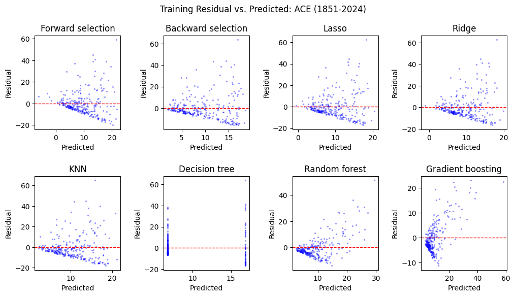

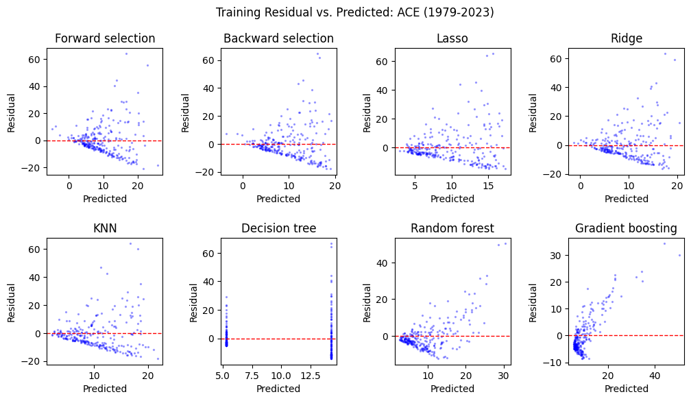

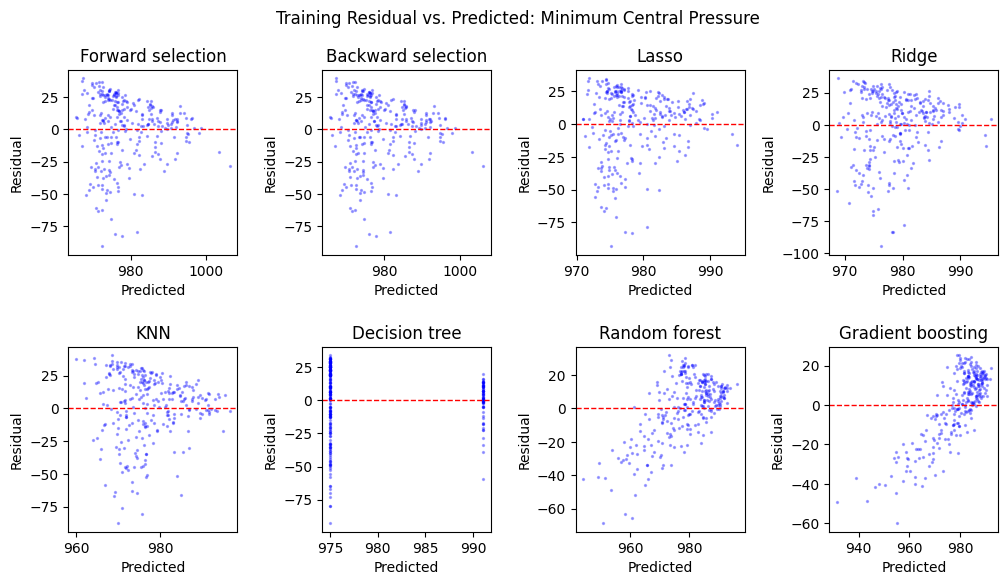

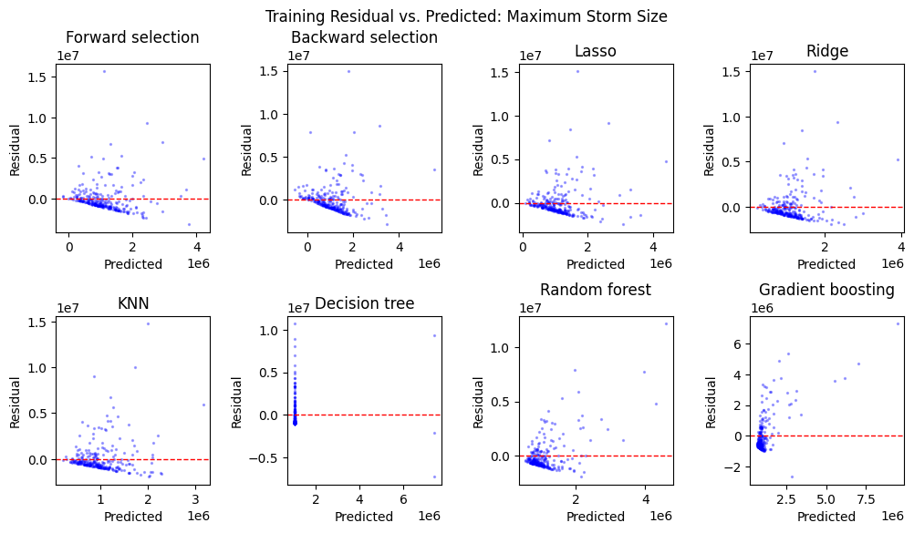

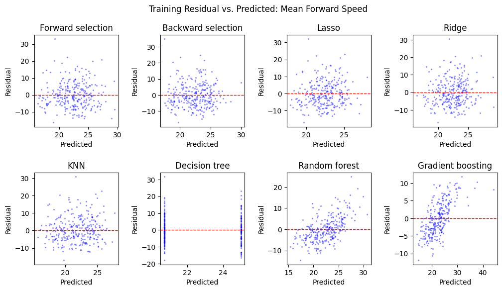

```python
problem_mapper = {
	"ace_all": "ACE (1851-2024)",
	"ace_satellite": "ACE (1979-2023)",
	"pressure": "Minimum Central Pressure",
	"size": "Maximum Storm Size",
	"forward_speed": "Mean Forward Speed"
}

for id in results.keys():
	scores = results[id]['scores']
	models = results[id]['best_models']
	X_train = results[id]['X_train']
	y_train = results[id]['y_train']
	X_test = results[id]['X_test']
	y_test = results[id]['y_test']
	fig, ax = plt.subplots(nrows = 2, ncols = 4, figsize=(3*4, 3*2))
	plt.subplots_adjust(hspace=0.5, wspace=0.5)
	for i, curr_ax in enumerate(ax.flatten()):
		curr_ax.axhline(y=0, linestyle='--', color='r', linewidth=1)
		y_train_pred = list(models.values())[i].predict(X_train)
		curr_ax.scatter(y_train_pred, y_train - y_train_pred, color='b', s=2, alpha=0.3)
		curr_ax.set_title(scores.index[i])
		curr_ax.set_xlabel("Predicted")
		curr_ax.set_ylabel("Residual")

	fig.suptitle(f"Training Residual vs. Predicted: {problem_mapper[id]}")
	plt.show()
```

For ACE and maximum storm size questions, we see a clear fan shape in most of our regression methods. That is, the residuals get larger in magnitude as the outcome variable increases. The exception is the simple decision tree, where the poor explanatory power of the variable resulted in the cross-validation process selecting a stump as the best option.

For minimum central pressure and mean forward speed, we see mostly random noise in the plots.

Then, we do the same for test residuals:

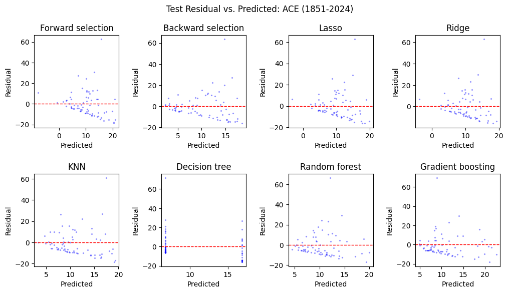

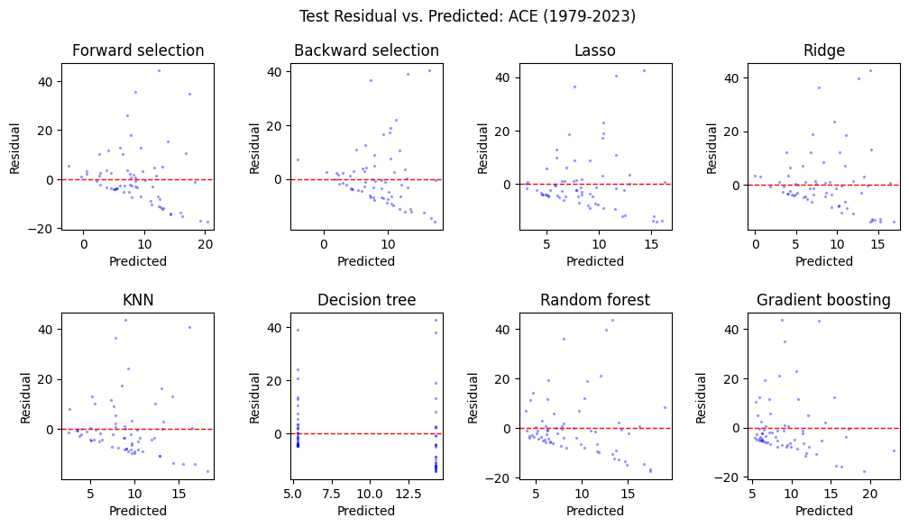

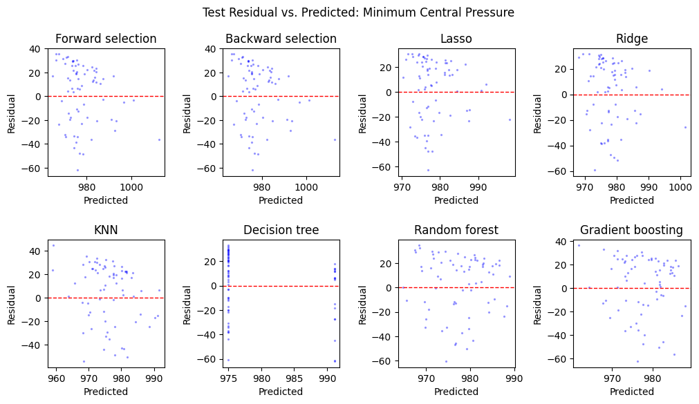

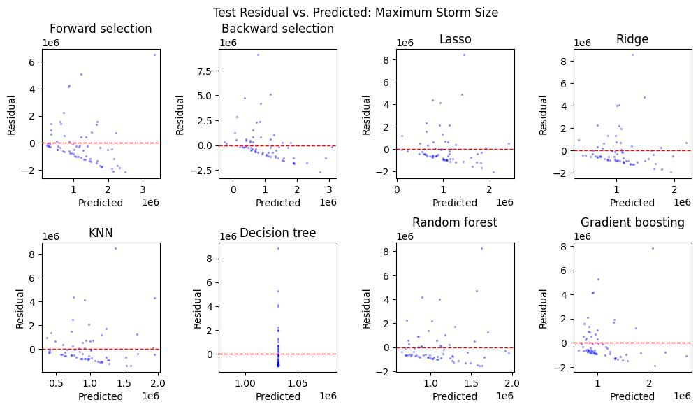

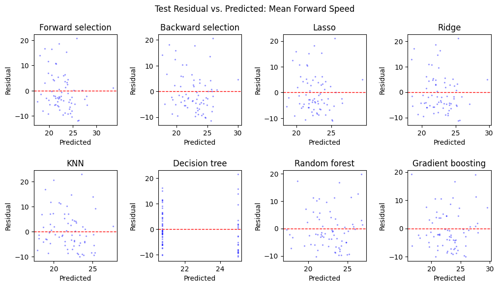

```python
for id in results.keys():
	scores = results[id]['scores']
	models = results[id]['best_models']
	X_train = results[id]['X_train']
	y_train = results[id]['y_train']
	X_test = results[id]['X_test']
	y_test = results[id]['y_test']
	fig, ax = plt.subplots(nrows = 2, ncols = 4, figsize=(3*4, 3*2))
	plt.subplots_adjust(hspace=0.5, wspace=0.5)
	for i, curr_ax in enumerate(ax.flatten()):
		curr_ax.axhline(y=0, linestyle='--', color='r', linewidth=1)
		y_test_pred = list(models.values())[i].predict(X_test)
		curr_ax.scatter(y_test_pred, y_test - y_test_pred, color='b', s=2, alpha=0.3)
		curr_ax.set_title(scores.index[i])
		curr_ax.set_xlabel("Predicted")
		curr_ax.set_ylabel("Residual")

	fig.suptitle(f"Test Residual vs. Predicted: {problem_mapper[id]}")
	plt.show()
```

The test residuals give us essentially identical behavior as the training residuals: fanning out for ACE and maximum storm size, non-linear noise for mean forward speed and minimum central pressure.

These models are extremely poor performers. However, for illustrative purposes, we chart the relative importances of predictors in one of our prediction problems: ACE (1851-2024):

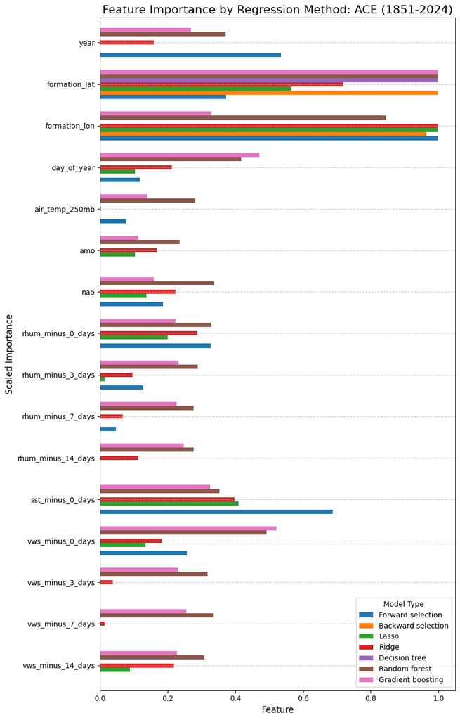

```python
ace_all_models = results["ace_all"]["best_models"]
importance_df = pd.DataFrame(columns=X_train.columns)
mask_forward = ace_all_models['Forward selection'].named_steps['sfs'].get_support()
coefs_forward = ace_all_models['Forward selection'].named_steps['model'].coef_.flatten()
importances_forward = np.zeros(X_train.shape[1])
importances_forward[mask_forward] = abs(coefs_forward)
importance_df.loc['Forward selection',:] = importances_forward
mask_backward = ace_all_models['Backward selection'].named_steps['sfs'].get_support()
coefs_backward = ace_all_models['Backward selection'].named_steps['model'].coef_.flatten()
importances_backward = np.zeros(X_train.shape[1])
importances_backward[mask_backward] = abs(coefs_backward)
importance_df.loc['Backward selection',:] = importances_backward
importance_df.loc['Lasso',:] = abs(ace_all_models['Lasso'].coef_)
importance_df.loc['Ridge',:] = abs(ace_all_models['Ridge'].coef_)
importance_df.loc['Decision tree',:] = ace_all_models['Decision tree'].feature_importances_
importance_df.loc['Random forest',:] = ace_all_models['Random forest'].feature_importances_
importance_df.loc['Gradient boosting',:] = ace_all_models['Gradient boosting'].feature_importances_

row_maximums = importance_df.max(axis=1)
importance_df = importance_df.div(row_maximums, axis=0)

plt.style.use('default')
ax = importance_df.T.iloc[::-1].plot(
    kind='barh',
    figsize=(9,14),
    rot=0,
	width=0.7,
	fontsize=10
)
plt.title('Feature Importance by Regression Method: ACE (1851-2024)', fontsize=16)
plt.xlabel('Feature', fontsize=12)
plt.ylabel('Scaled Importance', fontsize=12)
ax.legend(
    title='Model Type'
)
plt.grid(axis='y', linestyle='--', alpha=0.7)
plt.tight_layout()
plt.show()
```

## 8. Resource allocation and conclusions

### 8.1 Resource allocation

Although our damage proxies (ACE, minimum pressure, storm size, forward speed) are indirect substitutes for real economic loss, they represent intrinsic cyclone intensity and therefore provide a meaningful way to test early-stage predictability.

Unfortunately, our models failed at accomplishing this. However, the resource allocation question is still of interest: How can emergency management decision-makers best anticipate future resource deployment needs from an incoming cyclone?

Most hurricane damage is from a combination of high wind speed and storm surge, which is itself a function of wind speed and pressure, along with extrinsic characteristics of the location of landfall. The larger a cyclone is, the more widespread its damage. The slower it moves, the longer it pummels the towns it hits.

Because our models use only formation-day conditions, if they worked, they could have extended the planning window by up to 10–14 days depending on the formation spot, which is well before physical intensity forecasts become reliable. Even approximate forecasts help agencies triage storms and decide where to focus limited resources.

ACE predictions could have allowed agencies to quickly flag storms with high destructive potential, enabling pre-emptive mobilization of evacuation transport, hospital surge capacity, emergency fuel reserves and coastal protection teams before the storm begins intensifying. Officials can ramp up resource deployment over a longer time period. Early knowledge of a cyclone’s destructive potential also helps state governments determine whether to request federal assistance sooner, and how much. Moreover, being able to forecast central pressure, storm size, and forward speed supports more informed resource planning.

Our secondary prediction problems also would have been useful information to these decision makers: Low central pressure, large storm size, and low forward speed can cause significantly more damage to life and property through sustained wind and storm surge than another cyclone with the same top wind speed.

Quantitatively, it is difficult to characterize our particular resource allocation question. We deliberately avoid dollar amounts of damage as a metric because, as noted above, it is so dependent on extrinsic properties like location of landfall, angle of approach, steepness of ocean shelf, and pre-existing ground saturation from previous rainfall. However, an analysis by NOAA's National Centers for Environmental Information (NCEI) on the inflation-adjusted cost of U.S. cyclones highlights how the most costly cyclones were not the highest wind speeds. For example, Hurricane Katrina (ranked first, $210.3B) was Category 3, and Hurricane Sandy (ranked fifth, $88.5B) was only a Category 1. This emphasizes the importance of our secondary outcome variables in painting a more comprehensive picture of a cyclone's intrinsic destructive potential. We acknowledge that, without precise foresight of the landfall, any resource allocation application of a successful version of our model would necessarily have to be fairly broad in terms of dollar amounts.

So, while we are convinced of the importance of our research questions, we are disappointed in the failure of the models.

### 8.2 Conclusions

As illustrated above, our regression models for various indicators of ultimate cyclone destructive power uniformly failed to make accurate predictions based solely on weather conditions at time of formation.

We acknowledged this would potentially be the result of our study from the outset, given the incredible sophistication of the physical simulations used by meteorologists today. Our fears were strengthened by the lack of visible relationships between our many predicts and any of our four outcome variables, and then finally confirmed by our results. The weak associations across predictors indicate that the environmental factors present on, or immediately before, the formation day explain only a very small portion of the variability in the conditions that fuel a cyclone’s eventual strength.

We believe we executed well on the principles of data analysis and showcased good habits in our data collection, cleaning, and training steps, but ultimately it is clear that, at minimum, the predictors we selected are far from sufficient on their own to explain a cyclone's eventual power to any degree.

Because there are only so many cyclones in recorded history, we sought to include data as far back as we could. In order to check whether this was a mistake, we ran an alternate problem only on more recent, satellite-gathered data as well. In the end, neither time period of our predictors showed any explanatory power.

It is possible that a more comprehensive model could outperform ours, but our results are so convincing in their lack of applicability, that we do not recommend further study on this front.

## 9. References

Colbert, A. (2022, June 1). *A force of nature: Hurricanes in a changing climate.* NASA. https://science.nasa.gov/earth/climate-change/a-force-of-nature-hurricanes-in-a-changing-climate

National Oceanic and Atmospheric Administration. (2023). *Hurricane costs.* NOAA. https://coast.noaa.gov/states/fast-facts/hurricane-costs.html

Ghahremani, K., Bailey, J., & Amoroso, S. (2024). Hurricane Damage to Residential Structures: Wind Damage Overview. Forensic Engineering 2024, p274 - 281. https://doi.org/10.1061/9780784485798.030

Regnier, E. (2006). Public evacuation decisions and hurricane track uncertainty. Naval Postgraduate School. https://calhoun.nps.edu/entities/publication/30baa228-5644-4c74-81fd-30f9e9a68e45

Young, R., & Hsiang, S. (2024). Mortality caused by tropical cyclones in the United States. Nature, (635), 1–8. https://doi.org/10.1038/s41586-024-07945-5

Pandey, S., & Rao, A. (2019). Impact of Approach Angle of an Impinging Cyclone on Generation of Storm Surges and Its Interaction with Tides and Wind Waves. Journal of Geophysical Research: Oceans,124(11),7643-7660. https://doi.org/10.1029/2019JC015433

Shamsu, M., & Akbar, M. (2023). Understanding the effects of wind intensity, forward speed, and wave on the propagation of Hurricane Harvey surges. Journal of Marine Science and Engineering, 11(7), 1429. https://doi.org/10.3390/jmse11071429

NOAA National Centers for Environmental Information. (2025, January 10). *Costliest U.S. tropical cyclones.* https://www.ncei.noaa.gov/access/billions/dcmi.pdf

[GitHub repository of pre-processed data files and processing notebooks](https://github.com/lukefg/eneres-131-final-project)